# MultiEnvironmentTrial

# 1 Introduction

This tutorial introduces use to the main functions of the `MegaLMM` R package.

We will use `MegaLMM` to do Genomic Prediction for a set of maize lines in a large multi-environmental trial. Multi-environment trials are used to evaluate candidate varieties under different environments to learn which varieties might be useful for particular locations. This is important because **Gene-Environment Interactions** are very common in plants, which means that the relative performances of varieties may change across different environments, so the same line won’t necessarily be best everywhere.

Gene-environment interactions are often thought of as reaction norms, where we plot the change in a line’s performance as a function of the environment. However, an equivalent model for gene-environment interactions is to think of the trait value in each environment as a separate trait, and model the correlation in trait values across environments. As reaction norms, gene-environment interactions are represented by lines with different slopes. As correlated traits, gene-environment interactions are represented by correlations in traits that are less than one.

In `MegaLMM` we model gene-environment interactions as correlated traits, because this takes advantage of `MegaLMM`’s ability to model the covariances among a large number of traits. We will use `MegaLMM` to estimate the additive genetic and non-additive genetic covariances among all trials, and then use these covariances to predict the genetic values of every line in every trial. This is particularly useful when multi-environmental trials are *incomplete* meaning that not every line is evaluated in every trial. Specifically, we will leverage the relative line performances in some trials and the covariances among trials to predict the line performances in trials where they were not observed. We will use **cross-validation** to evaluate the accuracy of these predictions, and compare them to predictions in each trial that we would have made treating each trial independently.

The data are based on data from the [Genomes To Fields Initiative](https://www.genomes2fields.org/) which is a large consortium growing maize hybrids across a large number of trials across North America, but have been anonymized and subsetted to a smaller set for demonstration.

# 2 Preliminaries

We will use the `MegaLMM`, `rrBLUP`, and `ggplot2` packages.

`rrBLUP` and `ggplot2` can be installed from CRAN if you do not have them already:

```r
if(!require(rrBLUP)) { install.packages("rrBLUP"); library(rrBLUP) }
if(!require(ggplot2)) { install.packages("ggplot2"); library(ggplot2) }
```

`MegaLMM` is installed from GitHub:

```r
if(!require(devtools)) { install.packages("devtools"); library(devtools) }
if(!require(MegaLMM)) {
  devtools::install_github('deruncie/MegaLMM')
  library(MegaLMM)
  }
```

# 3 Load the data and format for MegaLMM

The data files for this tutorial are included with the `MegaLMM` package and can be accessed with the `data()` function:

Yield data are in the file `Yield_trial_BLUPs` and include 3,318 yield measurements from 502 lines and 19 environments.

```r
data('yield_data',package='MegaLMM')
yield_data
```

| Line | Population | Env | Yield |
| --- | --- | --- | --- |
| Line001 | 1 | Env01 | 0.0766365985 |
| Line001 | 1 | Env02 | 0.5736227692 |
| Line001 | 1 | Env03 | -0.1057395908 |
| Line001 | 1 | Env04 | 0.4053486537 |
| Line001 | 1 | Env05 | -0.0963883624 |
| Line001 | 1 | Env12 | 0.0750214507 |
| Line002 | 1 | Env01 | -0.0342987695 |
| Line002 | 1 | Env02 | -0.0400434704 |
| Line002 | 1 | Env03 | -0.2653557043 |
| Line002 | 1 | Env04 | 0.1136819932 |

[output cut: 990 more lines]

We can see the incidence matrix of lines by environments using the `Image` function in `MegaLMM`

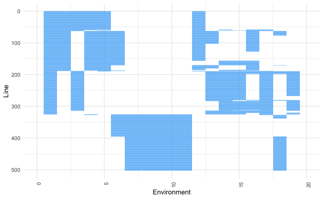

```r
Image(as.matrix(table(yield_data$Line,yield_data$Env))) + theme(legend.position = 'none') + xlab('Environment') + ylab('Line')
```

We can look at the number of observations by line and by environment:

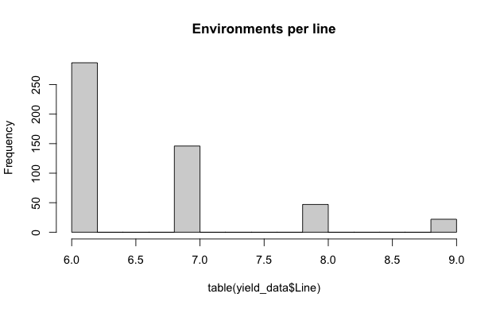

```r
hist(table(yield_data$Line),main = 'Environments per line',breaks=20)
```

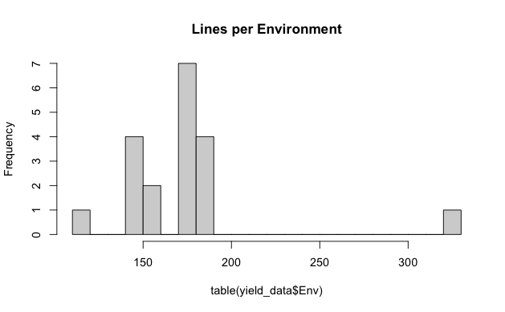

```r
hist(table(yield_data$Env),main = 'Lines per Environment',breaks=20)
```

The genetic data is available as an additive genomic relationship matrix calculated from GBS SNPs.

```r
data('K',package='MegaLMM')
```

We can view the matrix also using `Image`

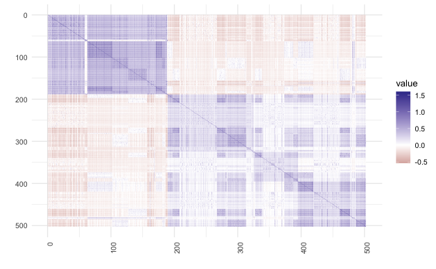

```r
Image(K)
```

This shows we also have two groups of fairly related lines, with low relationships between groups.

## 3.1 Formatting data from `MegaLMM`

The yield data was provided in the **tall** format, meaning a single observation per row. In this format we would say we have 1 trait (`Yield`) with values measured in many environments.

But `MegaLMM` isn’t good for modeling GxE like this. Instead, we want to consider the yield in each environment as a separate trait, and each line is measured for 6-9 of these traits. So we need to construct a `502x19` trait matrix. The `MegaLMM` package includes a helper function to do this called `create_data_matrices`. This uses `tidyr`’s `pivot_wider` function to create the matrix, and the arguments are the same.

```r
data_matrices = create_data_matrices(
  tall_data = yield_data, # your input tall data.frame,
  id_cols = c('Line','Population'), # vector giving the set of columns of tall_data used to identify each individual, and any covariates you'll want to use to model the trait data across individuals.
  names_from = 'Env', # vector giving the set of columns of tall_data used to identify each trait
  values_from = 'Yield' # name of the trait data column
)
```

The output of `create_data_matrices` is a list with 3 elements. We’ll only use the first two.

The first is a new data.frame with one row per individual, and a single column giving the Line identifier. If you have covariates among lines (e.g. sex, population, etc), those variables should be included here too.

```r
sample_data = data_matrices$data
sample_data
```

| Line | Population |
| --- | --- |
| Line001 | 1 |
| Line002 | 1 |
| Line003 | 1 |
| Line004 | 1 |
| Line005 | 1 |
| Line006 | 1 |
| Line007 | 1 |
| Line008 | 1 |
| Line009 | 1 |
| Line010 | 1 |

[output cut: 492 more lines]

The second is the `nxp` trait matrix. The rows of the trait matrix are aligned with the rows of the individual identifier data.frame. We can extract these for use in `MegaLMM`:

```r
Y = data_matrices$Y
head(Y)[,1:5]
```

```
              Env01       Env02      Env03      Env04       Env05
Line001  0.07663660  0.57362277 -0.1057396  0.4053487 -0.09638836
Line002 -0.03429877 -0.04004347 -0.2653557  0.1136820 -0.00372635
Line003  0.21059771 -0.63959202  0.3995948  0.2926501  0.11464992
Line004 -0.75226609 -0.14319441 -1.2009773 -0.4363149 -0.24941693
Line005  0.50406848  0.14874755  0.6330452  0.6561490  0.12371692
Line006 -0.02619325  0.16820004  0.1799732 -0.2938856  0.02111995
```

One check we need to do is ensure all our individuals in our data are represented in the genomic relationship matrix:

```r
all(rownames(K) %in% sample_data$Line)
```

```
[1] TRUE
```

```r
K = K[sample_data$Line,sample_data$Line]
```

# 4 Set up Cross Validation

The goal of genomic prediction is to accurately predict the genetic values of individuals that are not observed in a particular environment. The standard way to estimate this accuracy is to mask a portion of the lines in the input data, use a model to predict these masked values, and then measure the correlation between the predicted values and the original data. In this tutorial we will do only 1 round of a k-fold cross-validation. Generally you would repeat this with other training / testing partition.

Because we are evaluating the accuracy for incomplete multi-environment trial prediction, we will mask different set of individuals in each environment, so each individual maintains input data in at least some individuals.

Because the individuals are stratified between two populations, we will ensure all testing individuals come from the same population. The masking algorithm will be:

1. For each environment, decide which population is best represented
2. For the observed individuals in that population, divide them into k-folds
3. Create a matrix with the testing sets (fold_ID) for each observation

Not not worry about understanding this code! The call to `set.seed()` at the beginning makes it repeatable.

```r
set.seed(1)
k_fold = 5 # we will hold out 1/5 = 20% of the observations from each environment
fold_ID_matrix = matrix(NA,nrow = nrow(Y),ncol = ncol(Y),dimnames = dimnames(Y))
for(i in 1:ncol(fold_ID_matrix)) {
  observed_lines = sample_data[!is.na(Y[,i]),]
  pop = names(sort(table(observed_lines$Population),decreasing=T))[1]
  observed_lines = subset(observed_lines,Population == pop)
  n_lines = nrow(observed_lines)
  observed_lines$fold = sample(rep(1:k_fold,(n_lines/k_fold)+1))[1:n_lines]
  fold_ID_matrix[match(observed_lines$Line,rownames(fold_ID_matrix)),i] = observed_lines$fold
}
```

Now that we have divided the observed data into folds, we can chose to mask fold==1 to create our training data, and extract the corresponding values as our testing data

```r
fold_ID = 1
Y_train = Y_testing = Y
Y_train[fold_ID_matrix == fold_ID] = NA
Y_testing[fold_ID_matrix != fold_ID | is.na(fold_ID_matrix)] = NA
```

# 5 Run univariate GBLUP as reference

To evaluate whether the multi-trait prediction from `MegaLMM` is useful, we’ll run normal univariate genomic prediction using the GBLUP model using the `rrBLUP` package.

```r
library(rrBLUP)
rrBLUP_predictions = matrix(NA,nrow(Y),ncol(Y),dimnames = dimnames(Y))
for(i in 1:ncol(Y)) {
  X = model.matrix(~Population,sample_data) # we will include Population as a covariate if it is variable among the individuals for this environment
  if(var(X[!is.na(Y_train[,i]),2]) == 0) X = X[,-2]
  rrBLUP_predictions[,i] = mixed.solve(y = Y_train[,i],
                                       X = X,
                                       K = K)$u
}
```

Here are the correlations between the predictions and the testing data:

```r
diag(cor(Y_testing,rrBLUP_predictions,use='p'))
```

```
       Env01        Env02        Env03        Env04        Env05        Env12        Env14        Env16        Env17
 0.278425958  0.187881694  0.625000316  0.389125876 -0.033478375  0.029312407 -0.109251579  0.339391947  0.334737933
       Env15        Env06        Env13        Env18        Env19        Env07        Env08        Env09        Env10
 0.373848343 -0.272951670  0.111330746  0.426321031  0.002766824  0.309384501  0.349614409 -0.097410915  0.104172216
       Env11
-0.071876574
```

# 6 Run MegaLMM

Now, we’ll move to `MegaLMM` and fit a multivariate GBLUP model to all trials at once.

First, I’ll review the `MegaLMM` model, and then describe the implementation and usage of the `R` package.

## 6.1 Background

#### 6.1.0.1 The MegaLMM model

**MegaLMM** implements multivariate linear mixed models of the form:

```
Y = X*B + Z*U + E
```

where `Y` is a `n x t` matrix of observations for `n` individuals and `t` traits, `X` is a design matrix for `b` fixed effects (including an intercept), `Z` is a design matrix for the random effects, and `E` is a `n x t` matrix of residual errors. The random effects are `U` are independent of the residuals, but columns of `U` matrix can be correlated, and each column vector marginally follows a multivariate normal distribution with a known covariance matrix `K`.

MvLMMs like this are notoriously difficult to fit. We address this by re-paramterizing the MvLMM as a mixed effect factor model:

```
Y = F*Lambda + Y_R
Y_R = X*B_R + Z*U_R + E_R
F = X*B_F + Z*U_F + E_F
```

where `F` is a `n x k` matrix of latent factor traits and `Lambda` is a `k x t` matrix of factor loadings. This is the model actually fit by **MegaLMM**. Basically, we break `Y` which is a set of `t` correlated traits into two sets of uncorrelated traits: `Y_R` and `F`. These are sets of `t` and `K` traits all of which are independently related to the fixed and random effects. All covariances within and among these sets of traits are captured by `Lambda`. Because of this, we can treat each of the columns of `Y_R` or `F` independently and specific a LMM for each of them. Generally, we use the same `X`, `Z` and `K` for all these traits. However in `MegaLMM` we allow some additional flexibility:

- The fixed effect design matrix `X` is split into two parts: `X_1` and `X_2`. `X_1` are true fixed effects meaning the corresponding coefficients (`B_1`) are given flat priors. Because of this, we can’t allow `F` to depend on `X_1`, so this is only part of the model for `Y_r`. `X_2` are regularized effects, so the corresponding coefficients are given an informative prior (e.g. BayesC). We allow both `Y_R` and `F` to depend on `X_2`, and potentially on different subsets of `X_2`: `X_2F` and `X_2R`, with corresponding coefficient matrices `B_2F` and `B_2R`. We do not make use of these matrices in this tutorial. The full models thus are: `Y_R = X_1*B_1 + X_2R*B_2R + Z*U_R + E_R` and `F = X_2F*B_2F + Z*U_F + E_F`.
- While the same model structure applies to all columns of `Y_R`, because of missing values not all columns of `X_1` may be variable for a particular trait. Therefore we drop columns of `X_1` as needed and assign the coefficients to 0.
- While I only wrote a single random effect above, `MegaLMM` does allow you to specific multiple independent random effects with different covariance matrices. However the memory and time complexities increase exponentially with more random effects. And, we cannot account for correlations among `U_i` and `U_j`.

Taking a single column of `Y_R`, the LMM is:

$$y_r = X\times b_r + Z\times u_r + e_r \\
u_r \sim N(0,\sigma^2*h^2*K) \\
e_r \sim N(0,\sigma^2*(1-h^2)*I)$$

The model for each column of `F` is similar. This differs from most Bayesian LMMs in the parameterization of the variance components, but has some conceptual and algorithmic advantages. For priors, we use an inverse gamma prior for $\sigma^2$ and a discrete prior on $h^2$. Specification of the priors is described below.

The unique aspects of **MegaLMM** relative to other factor models are:

1. The residuals of `Y` after accounting for the factors are not assumed to be iid, but are modeled with independent (across traits) LMMs accounting for both fixed and random effects.
2. The factors themselves are also not assumed to be iid, but are modeled with the same LMMs. This highlights the parallel belief that these latent factors represent traits that we just didn’t measure directly.
3. Each factor is shared by all modeled sources of variation (fixed effects, random effects and residuals), rather than being unique to a particular source.
4. The factor loadings are strongly regularized so ensure that estimation is efficient. We accomplish this by ordering the factors from most-to-least important using a prior similar to that proposed by [Bhattarchya and Dunson (2011)](https://pubmed.ncbi.nlm.nih.gov/23049129/)

#### 6.1.0.2 Model formula

We use R’s `formula` syntax to construct the design matrices `X` and `Z`. In default usage, we specific a single formula and assume it applies to all columns of both `Y_R` and `F`, except the fixed effects do not apply to `F`.

#### 6.1.0.3 Random effects

The random effect syntax in a formula is `(a|X)`. This specifies a variance for each level of `a` (*e.g.* environment) for the location effects for each level of `X` (*e.g.* genotype, *i.e.* variance among genotypes in each environment). In `lme4` syntax, there would additionally be covariances between the levels of `a` within each level of `X`. However we cannot model these covariances in `MegaLMM`, so this syntax makes independent variances for each level of `a`. Note, however, that each level of `a` introduces a new variance into the model, which exponentially increases the memory requirements! It is much better, if possible, to introduce each level of `a` as a separate trait!

Random effects have two parts: **location effects** which are the values for each level (*e.g.* breeding values for each individual) and **variances** which are the population variances of the location effects. We model the location effects as following a multivariate normal distribution with covariance equal to a known covariance matrix (**K**) times a **variance proportion** ($h^2$) times a phenotypic variance ($\sigma^2$). This differs slightly from typical parameterizations of random effects, which uses a separate variance for each random effect. In `MegaLMM` we instead model the proportion that each random effect contributes to the total, so all $h^2_i$ values sum to 1, and use a discrete prior over the interval [0,1] for this parameter. This gives you a lot of flexibility for specifying prior distributions.

#### 6.1.0.4 Factors

In most factor models the number of factors `K` is a critical parameter, and models with different numbers of parameters (either larger or smaller than optimal) may give very different answers. This is generally not the case in `MegaLMM`. In `MegaLMM` we use a prior to order and regularize the importance of the factors, enforcing that high-order factors explain less and less of the overall variation. Therefore the highest-order factors are generally extremely unimportant, and adding a few more or fewer of these unimportant factors won’t change the influence of the first factors. It is important to set `K` large enough to capture most of the covariation in `Y`, but once it’s large enough, additional values will not likely affect the model much.

A related note, though, is that the precise ordering of the factors is not well learned by the MCMC algorithm, and so inferences that rely on this should be treated with extreme caution. The rate of decay of factor importance is highly sensitive to the prior, and factor ordering does not mix well. Routines are described below to help the convergence of factor ordering to a useful value, but that is all we can do. This also means that the precise values of individual factor loadings may drift during the MCMC as factor orderings change slowly. This would greatly impact the inference on factor identities, but is not very important if the goal is prediction of `U` or `Y`.

#### 6.1.0.5 Missing data

In a Bayesian model, we can treat missing data as additional parameters that need to be learned, so imputation of missing data happens naturally. However, if we construct the model correctly, some missing data points are not needed for the inference of any other parameters, and so can be simply predicted from the posterior values of other parameters. The more missing values we can treat this way the better, because conditioning on imputed values in MCMC greatly reduces the mixing rate of the chain.

In `MegaLMM`, if we can identify groups of traits that share missing values across a group of individuals (rows), we can declare that this block of values to be only predicted, not imputed. There is a tradeoff here in that the more groups of traits are specified, the greater the memory overhead of `MegaLMM`. But the improvement in MCMC mixing can be great.

#### 6.1.0.6 MCMC and Posterior samples

`MegaLMM` uses a Gibbs sampler to draw samples from posterior of all unknown parameters. There are a lot of parameters in the `MegaLMM` model, and not all of them may be of interest to a user. You can choose which specific parameters should be tracked as described below. Additionally, you may be interested in a function of several parameters, and there is a function to calculate these values on each iteration as well. Finally, the sets of posterior samples can themselves be very large. If you’re tracking large matrices of predicted values for thousands of traits these posterior samples can take of Gbs of memory. Therefore `MegaLMM` has a way to store the posterior samples as a database on the disk, only holding small chunks of a chain in memory at a time.